# Change in river water flow due to hydropower

NIVA_Flom (flood water flow)  
NIVA_Lavvann (winter water flow)

Authors

Affiliation

Dag Øystein Hjermann

Norwegian Institute for Water Research

Roar Brænden

Norwegian Institute for Water Research

Published

October 30, 2026

**TipMetadata**

Table 1: Indicator metadata

| Variable | Value |
| --- | --- |
| Indicator ID | NIVA_Flom; NIVA_Lavvann |
| Indicator Name | Change in river water flow due to hydropower |
| verbatimName | Endring i elvevannføring grunnet kraftutbygging |
| Country | Norway |
| Continent | Europe |
| Ecosystem Condition Typology Class | A1 - Physical state characteristics |
| Realm | Freshwater (F) |
| Biome | F1 Rivers and streams biome |
| Ecosystem | F1.2 Perm lowland rivers |
| verbatimEcosystem | Elv |
| Year added | 2026 |
| Last update | 2026 |
| Version | 0.1.0 |
| Version comment | First try |
| Normalised | TRUE |
| Spatial aggregation pathway | Scale - Aggregate |
| Precision |  |

**TipLog**

- 01 Jan. 1901 - Original PR

## 1. Summary

The natural pattern of river water flow in most parts of Scandinavia is low flow during winter, when most precipitation comes in the form of snow, and with a flood peak during spring and early summer when the snow melts. Hydropower development involving large water reservoirs affects this pattern, typically by increasing the water flow during winter and decreasing water flow during spring and early summer. This indicator uses measurements of water flow from NVE’s stations during the last 20 years and compares it with estimates of natural water flow at the same locations, using NVE’S NEVINA model tool.

## 2. About the underlying data

There are two main datasets of underlaying data:

1. Measured low-flow indices and flood values for rivers (at the posiotion of river flow measurement stations) Low-flow indices was set to the 5% percentile of water flow during the winter months (1. October-30. April) in both cases.
2. Estimated low-flow indices and flood values for rivers (at the posiotion of river flow measurement stations) if the upstream river catchment was unaffected by hydropower development. The estimates were found using NEVINA, which calculates catchment boundaries and catchment characteristics based on natural watershed boundaries. This means that existing regulations, reservoirs, or other hydrological alterations within the catchment are not taken into account. All catchment characteristics, low-flow indices, and flood values are calculated automatically. The estimates are based on the observed climate in the period 1991-2020.

### 2.1 Spatial and temporal resolution and extent

Point-based measurements.

### 2.2 Sampling design

BAsed on NVEs network of river flow stations

### 2.3 Original units

Cubic meters/second.

### 2.4 Instructions for citing, using and accessing data

### 2.5 Additional comments about the dataset

## 3. Indicator properties

### 3.1 Ecosystem Condition Typology Class (ECT)

The indicator is assigned to “A1 - Physical state characteristics” as it relates to extremes of water flow, which affects the physical effects of river and river-related habitats. For instance, with decreasing floods, sand banks along the rivers become colonised by plants and sand banks no longer functions as a habitat for specialised, red-listed species.

### 3.1.1 Other condition typologies

### 3.2 Ecosystem condition characteristic

### 3.3 Collinearities with other indicators

### 3.4 Impact factors

The specific impact factor in this analysis is hydropower development. Other impact factors are area use (especially extent of agricultural and urban land) and climate change. These are specifically not taken into account.

### 3.5 Spatial aggregation

The variables are scaled at the point level and then aggregated.

## 4. Reference condition and levels

### 4.1 Reference condition

The reference condition is that seasonal water flow patterns are unaffected by upstream hydropower development. Note that the NEVINA estimates used to estimate reference levels of flood and low-water is based on the current land area use, including agricultural fields which also affect flood levels (NVE 2025).

### 4.2 Reference levels

Reference condition for seasonal water flow patterns are based on calculations done by Nevina.

#### 4.2.1 Spatial resolution and validity

## 5. Uncertainties

### 5.1 General uncertainties

The mathematical model used in NEVINA is based on the runoff map for the 1961-1990 period. We have used the runoff map for 1991-2020 as input to this model, but as the model itself has not been updated, this constitutes a source of error and possibly also an unknown bias.

### 5.2 Reported uncertainties

We report the statistical uncertainty, i.e. the standard error of the weighted mean of the indicator.

## 6. References

Hofstad, Knut; Halleraker, Jo Halvard; Bakken, Tor Haakon 2026. Vannkraft. Store norske leksikon på snl.no. Retrieved 29. oktober 2026 from https://snl.no/vannkraft.

NVE 2205. NEVINA Brukerveiledning. Retrieved 29. oktober 2026 from https://publikasjoner.nve.no/diverse/2025/Brukerveiledning.i.Nevina2025.pdf.

## 7. Import and prepare datasets

### 7.1 Observed river flow

We use the observed daily riverflow from the last 20 years that data are available (2004-2023).

```r
# read data and station data (the latter includes NEVINA calculations)

# run if "dat" doesn't exist in memory
# (just to save a little time when debugging)
if (!"dat" %in% ls()){

  dat <- read_csv("../data/seriedata.zip") |>
    mutate(
      year = lubridate::year(date),
      month = lubridate::month(date)
    )

}
cat("Number of measurements:", nrow(dat), "\n")
```

```
Number of measurements: 2555222
```

```r
cat("Number of stations:", length(unique(dat$stasjonsnr)), "\n")
```

```
Number of stations: 364
```

```r
cat("Time coverage:", min(dat$date), "-", max(dat$date), "\n")
```

```
Time coverage: 12418 - 19721
```

```r
head(dat, 3) |> kable(caption = "Data sample (one station, three days)")
```

Data sample (one station, three days)

| stasjonsnr | date | dailyQ_m3s | year | month |
| --- | --- | --- | --- | --- |
| 2.268.0 | 2004-01-01 | 1.544084 | 2004 | 1 |
| 2.268.0 | 2004-01-02 | 1.544084 | 2004 | 1 |
| 2.268.0 | 2004-01-03 | 1.544084 | 2004 | 1 |

### 7.2 Estimated flood and low-water values for natural watershed

These are estimates of the mean flood (highest daily water flow over a year) and low-water values (5% percentiles) of water flow through the winter (1. October-30. April), esimated using the NEVINA tool offered by NVE (nevina.nve.no), For mean flood, we used the estimates based on “Regional flomfrekvensanalyse” (RFFA-2018). Is input, we used the observed meteorological data (precipitation, snow, temperature, etc.) for the 30-year period 1991-2020.

```r
stations_orig <- read_seriestasjoner("../data/seriestasjoner.csv")

head(stations_orig, 3) |> kable(caption = "Data sample (three stations)")
```

Data sample (three stations)

| stasjonsnr | navn | areal_km2 | sjo_prosent | normalQ_m3s | lowflow_m3s | nifs_high_m3s | rffa_high_m3s | highflow_m3s |
| --- | --- | --- | --- | --- | --- | --- | --- | --- |
| 121.20.0 | Åmot | 283.23 | 5.57 | 7.678365 | 0.6982512 | 76.85594 | 64.02042 | 64.02042 |
| 26.20.0 | Årdal | 76.90 | 9.23 | 5.989741 | 0.3635417 | 54.21227 | 41.28056 | 41.28056 |
| 2.32.0 | Atnasjø | 462.13 | 1.97 | 10.185345 | 0.7061582 | 108.75537 | 78.93888 | 78.93888 |

### 7.3. Watershed metadata

These data was downloaded from seriekart.nve.no and contains a large number of variables for the catchment of each measurement station. The most interesting ones for our analysis are the indices of hydropower regulation and hydropower dams, which both on scale 0-1 and indicate how much of the catchment that is affected by hydropower regulation (including run-of-river hydro power stations) and hydropower regulation dams (“Reguleringsgrad magasin”). We focused on the latter, hereby called **dam index**. For many stations these indices are small or zero, but they mostly have quite small catchments.

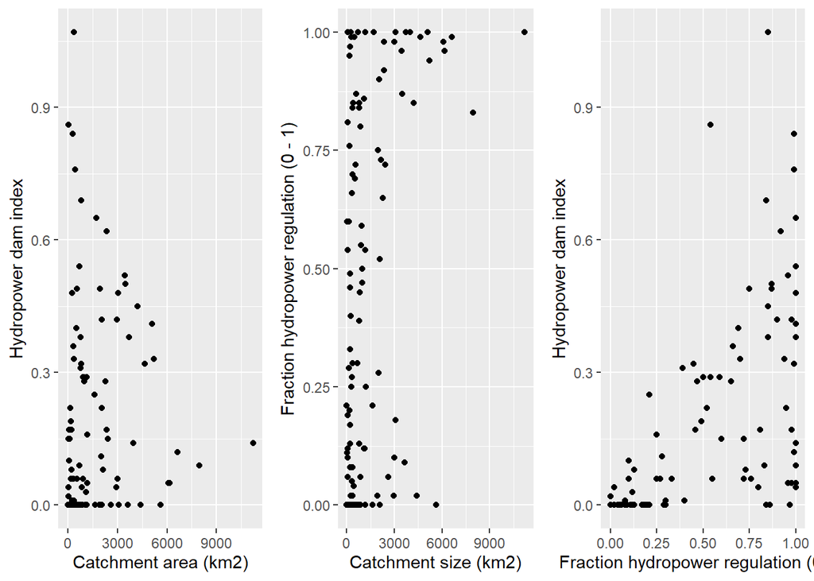

```r
# add degree of hydropower dams to the station data

# all metadata
stations_meta <- readr::read_csv("../data/seriestasjoner_meta.csv", col_types = columntypes_meta, na = c("NA", "Ikke angitt"))

# spec(stations_meta)
# names(stations_meta)

# we pick degree of hydropower dams, change column name, and add that column to 'stations_orig'

stations_meta <- stations_meta |>
  rename(
    steepness = `Bratthet (1085-gradient, m/km)`,
    perc_bogs = Myrprosent,
    perc_lake = `Effektiv sjøprosent`,
    perc_agri = Jordbruksprosent,
    perc_forest = Skogprosent,
    perc_mount = Snaufjellprosent,
    perc_glacier = Breprosent,
    river_gradient = `Elvegradient (m/km)`,
    river_length = `Elvelengde (km)`,
    river_density = `Elvetetthet (m/km)`,
    alti_med = `Medianhøyde (m)`,
    alti_10p = `Høyde 10 persentil (m)`,
    alti_90p = `Høyde 90 persentil (m)`,
    altitude = `Høyde over havet (m)`,
    index_regul = `Reguleringsgrad areal`,
    index_dams = `Reguleringsgrad mag,`
  )

stations_orig2 <- merge(stations_orig, stations_meta, by =  "stasjonsnr")

# all metadata
stations <- stations_orig2 |>
  filter(!is.na(areal_km2) & !is.na(index_dams))

gg1 <- ggplot(stations, aes(x = areal_km2, y = index_dams)) +
  geom_point() +
  labs(x = "Catchment area (km2)", y = "Hydropower dam index")

gg2 <- ggplot(stations, aes(x = areal_km2, y = index_regul)) +
  geom_point() +
  labs(x = "Catchment size (km2)", y = "Fraction hydropower regulation (0 - 1)")

gg3 <- ggplot(stations, aes(x = index_regul, y = index_dams)) +
  geom_point() +
  labs(x = "Fraction hydropower regulation (0 - 1", y = "Hydropower dam index")

cowplot::plot_grid(gg1, gg2, gg3, nrow = 1)
```

#### Distribution of normal river flow

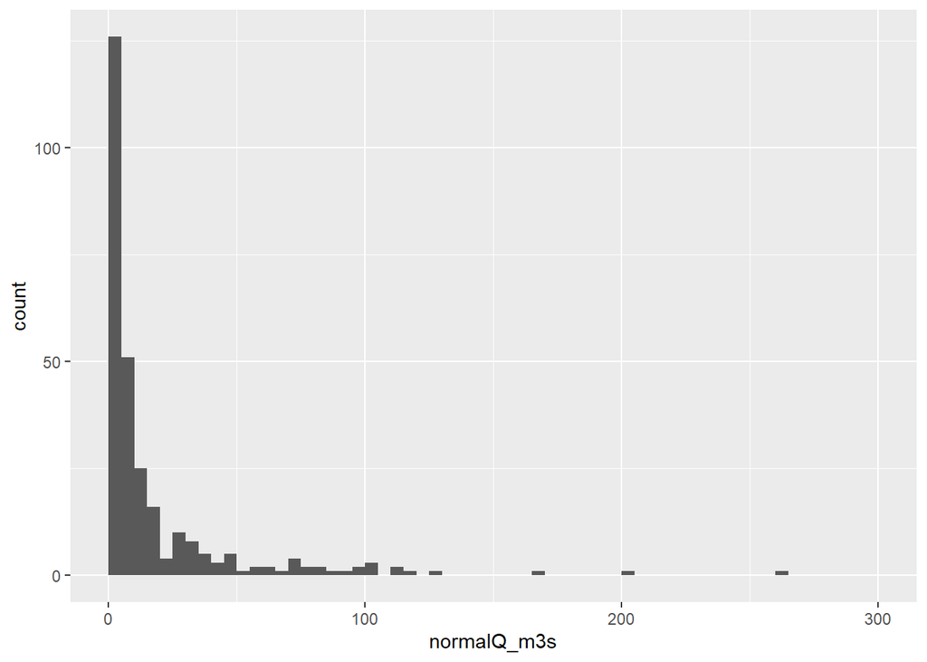

```r
ggplot(stations, aes(x = normalQ_m3s)) +
  geom_histogram(breaks = seq(0,300,5))
```

#### Number of stations by normal river flow (rows) and the dam index (columns).

```r
stations |>
  mutate(
    normalQ_m3s_c = cut(normalQ_m3s, breaks = c(0,3,5,10,20,50,100,300)),
    index_dams_c = cut(index_dams, breaks = seq(0,1,0.2), right = FALSE)
        ) %>%
  xtabs(~normalQ_m3s_c + index_dams_c, .)
```

```
             index_dams_c
normalQ_m3s_c [0,0.2) [0.2,0.4) [0.4,0.6) [0.6,0.8) [0.8,1)
    (0,3]          89         1         0         0       1
    (3,5]          34         0         1         0       0
    (5,10]         50         1         0         0       0
    (10,20]        37         1         1         1       1
    (20,50]        22         9         2         1       0
    (50,100]        8         3         5         2       0
    (100,300]       6         1         3         0       0
```

### 7.4 Spatial data of river flow stations

```r
geo_points <- sf::read_sf("../data/geo_points.gpkg")

county_order  <- c(
  "Finnmark", "Troms", "Nordland", "Trøndelag",
  "Møre og Romsdal", "Vestland", "Rogaland",
  "Buskerud", "Telemark", "Innlandet",
  "Agder", "Vestfold", "Oslo", "Akershus", "Østfold")
```

## 9. Analyses

### 9.1 Calculate observed flow statistics

For each station and year, we find the annual flood value (maximum river flow) and the winter low-flow value (the 5% of the months October to April). Then we find the mean and standard deviation of those values for every station. The two are (as expected) highly correlated (figure below).

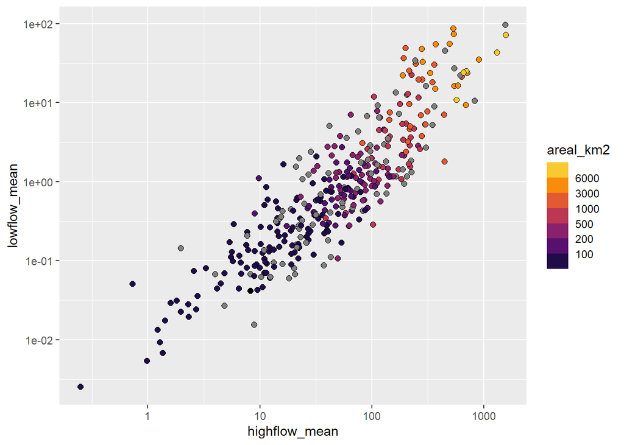

```r
# get observed means
flow_high <- yearly_highflow(dat)
flow_winter <- yearly_lowflow(dat)
flow_statistics <- flow_stats(flow_winter, flow_high)

flow_statistics |>
  left_join(stations, by = join_by(stasjonsnr)) |>
  ggplot(aes(highflow_mean, lowflow_mean, fill = areal_km2)) +
         geom_point(shape = 21, size = rel(2)) +
  scale_fill_viridis_b(breaks = c(0,100,200,500,1000,3000,6000, 12000), option = "inferno") +
  scale_x_log10() +
  scale_y_log10()
```

### 9.2 Indices and indicators

#### Calculate flood index and low-water indicator

The indices are calculated by comparing the observed statistics of flood and low-water flow with NEVINA’s estimates of the same parameters.

For floods, we started by creating a flood index (this index turned out to departure from 1 for rivers without dams, so the flood indicator will therefore be derived later). For river *i*, this is

$$\text{Flood\_index}_i
= 1 - \frac{Q_{\text{model,high,i}} - \overline{Q_{\text{obs,high,i}}}}
{Q_{\text{model,high,i}}}$$

The low-water indicator for river *i* depends on the both the modelled natural low-water flow as well as the observed mean flood. If the observed low-water flow is equal to the modelled natural low-water flow, the indicator is 1. If the observed low-water flow is equal to the observed flood flow, the indicator is 0.

$$\text{Lowwater\_indicator\}
= 1 - \frac{\overline{Q_{\text{obs,low}}} - Q_{\text{model,low}}}
{\overline{Q_{\text{obs,high}}} - Q_{\text{model,low}}}$$

where $Q_{\text{model,low,i}}$ is the modelled mean low water flow of river *i* from NEVINA, and $\overline{Q_{\text{obs,low,i}}}$ is the mean of the observed low water flow for the same river.

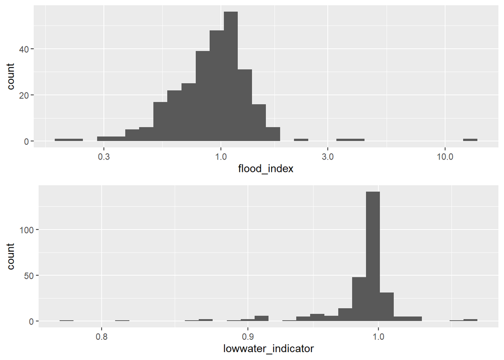

```r
# indicator 001: effect of hydropower on floods and low water
# indicator 002, : effect of hydropower on low water
dat_indekser_1 <- kalkuler_indikatorer(
  flowstats = flow_statistics,
  seriestasjoner = stations) |>
  mutate(log_areal = log10(areal_km2))

gg1 <- ggplot(dat_indekser_1, aes(flood_index)) +
  geom_histogram() +
  scale_x_log10()
gg2 <- ggplot(dat_indekser_1, aes(lowwater_indicator)) +
  geom_histogram() +
  scale_x_log10()
plot_grid(gg1, gg2, ncol=1)
```

#### Add geodata and county

```r
dat_indekser <- dat_indekser_1 |>
  left_join(geo_points,
            by = join_by(stasjonsnr), relationship = "many-to-one")  |>
  mutate(county = factor(county, levels = county_order)) |>
  st_as_sf(sf_column_name = "geom")
```

### 9.3. Spatial and altitudinal spread

#### Map 1 - color by dam index

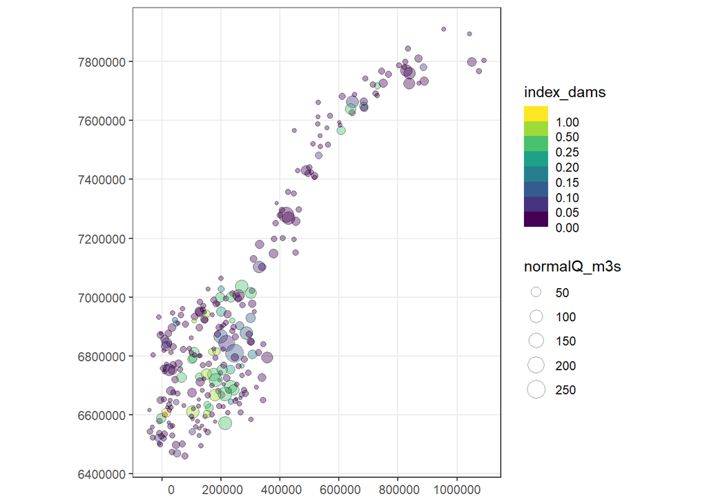

```r
ggplot(dat_indekser) +
  geom_sf(aes(geometry = geom, fill = index_dams, size = normalQ_m3s),
          shape = 21, alpha = 0.4)+
  scale_fill_viridis_b(
    breaks = c(0,0.05,0.1,0.15,0.2,0.25,0.5,1)) +
  theme_bw()
```

#### Map 2 - color by altitude

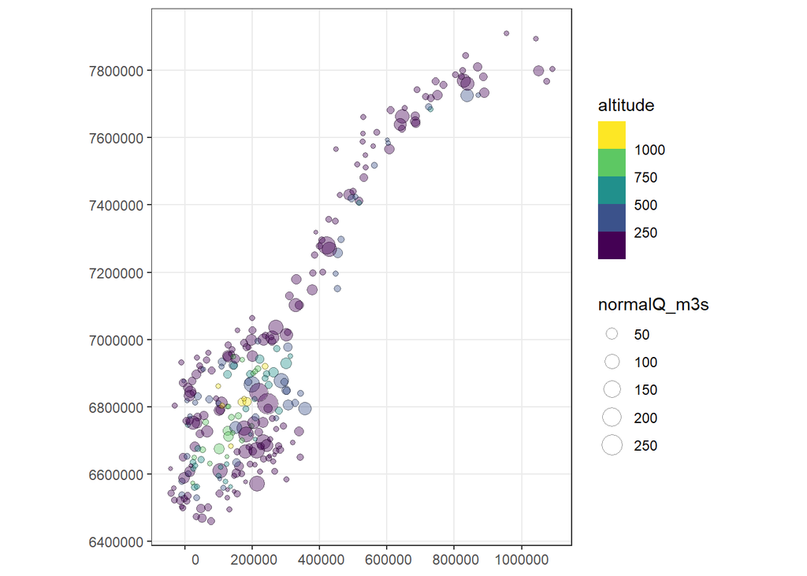

```r
ggplot(dat_indekser) +
  geom_sf(aes(geometry = geom, fill = altitude, size = normalQ_m3s),
          shape = 21, alpha = 0.4) +
  scale_fill_viridis_b() +
  theme_bw()
```

#### Number of stations by altitude

```r
# cut with non-scientific formatting
cut_noscient <- function(x, breaks){
  # format non-scientific
  breaks_str <- format(breaks, scientific = FALSE)
  # remove extra spaces
  breaks_str <- gsub(" ", "", breaks_str)
  # create labels
  labs <- paste0(
    "(", head(breaks_str, -1),
    ",",
    tail(breaks_str, -1),
    "]"
  )
  cut(x, breaks = breaks, labels = labs)
}
# debugonce(cut_noscient)
# cut_noscient(c(1:10,200), c(0,3,12,300))

# quantile(dat_indekser$altitude)
# quantile(dat_indekser$normalQ_m3s)
# dat_indekser |>
#   mutate(
#     altitude = cut_noscient(altitude, breaks = c(0,200,500,1300)),
#     `water flow (m3/s)` = cut(normalQ_m3s, breaks = c(0,5,20,50,100,300))
#   ) %>%
#   xtabs(~`water flow (m3/s)` + altitude, .)
#
# tab <- dat_indekser |>
#   mutate(
#     altitude = cut_noscient(altitude, breaks = c(0,200,500,1300)),
#     `water flow (m3/s)` = cut(normalQ_m3s, breaks = c(0,5,20,50,100,300))
#   ) %>%
#   xtabs(~`water flow (m3/s)` + altitude + (index_dams==0), .)

# tab[,,1]
# tab[,,2]
# tab_n <- tab[,,1] + tab[,,2]
# tab_p <- 100*round(tab[,,2]/(tab[,,1] + tab[,,2]), 3)
#
# tab_comb <- matrix("", dim(tab)[1], dim(tab)[2])
# rownames(tab_comb) <- 1:5
# nr = dim(tab)[1]
# nc = dim(tab)[2]
# for (i in 1:nr){
#   for (j in 1:nc){
#     tab_comb[i,j] <- paste0(tab_n[i,j], " / ", tab_p[i,j])
#   }
# }
# tab_comb |> knitr::kable()

dat_indekser |>
  mutate(
    altitude = cut_noscient(altitude, breaks = c(0,200,500,1300)),
    `water flow (m3/s)` = cut(normalQ_m3s, breaks = c(0,5,20,50,100,300))
  ) %>%
  xtabs(~`water flow (m3/s)` + altitude , .)
```

```
                 altitude
water flow (m3/s) (0,200] (200,500] (500,1300]
        (0,5]          57        27         41
        (5,20]         51        28         13
        (20,50]        27         3          5
        (50,100]       14         4          0
        (100,300]       7         3          0
```

### 9.4 Examine observed and modelled water flow

#### Observed and modelled natural flood values

In rivers affected, by hydropower, observed values of mean annual flood are expected to lie somewhere below modelled natural flood values.

Figure: Observed values of mean annual flood (y axis, red) and low-water value (y axis, blue) on y axis plotted towards modelled natural flood values (x axis). The line indicates y = x.

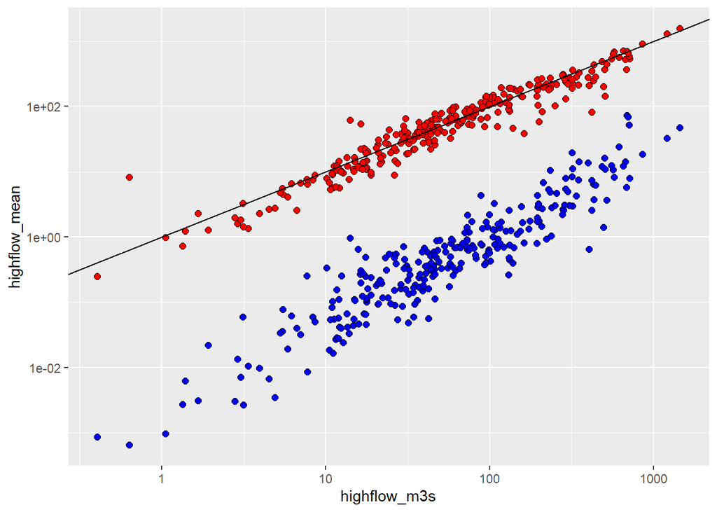

```r
ggplot(dat_indekser,
       aes(highflow_m3s, highflow_mean)) +
  geom_point(shape = 21, size = rel(2), fill = "red") +
  geom_point(aes(y=lowflow_m3s), shape = 21, size = rel(2), fill = "blue2") +
  geom_abline(intercept = 0, slope = 1) +
  scale_x_log10() +
  scale_y_log10()
```

#### Examine flood indices vs. indices of hydropower

As shown below (figure a), the index of effect of hydropower on floods varies around 1 for rivers were `index_dams` is zero (i.e. there are no dams in the catchment of the station). As the amount of dams increases, the index goes towards lower numbers. Thus, the flood indices appear to work well. As we see from figure b, `index_regul` (measuring all sorts of hydropower development, including run-of-river hydropower plants that has no large dam) is much less correlated to the flood indicator, indicating that this index is trule closely connected to presence of large dams upstream.

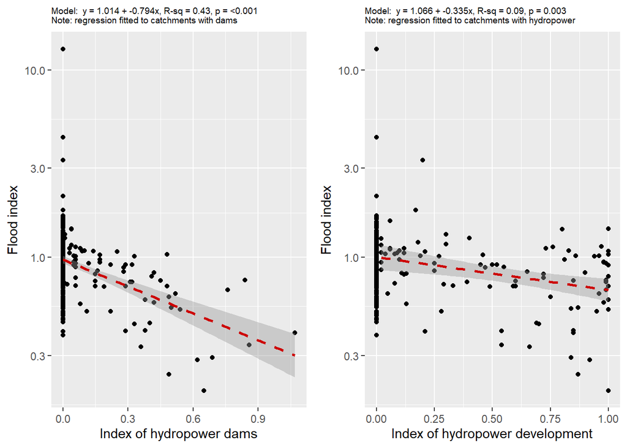

```r
# 1. index_dams

mod <- lm(flood_index ~ index_dams,
          data = dat_indekser |> filter(index_dams > 0),
          na.action = na.omit)

gg1 <- ggplot(dat_indekser, aes(index_dams, flood_index)) +
  geom_point() +
  geom_smooth(
    data = dat_indekser |> filter(flood_index > 0),
    method = "lm", linetype = "dashed", color = "red3") +
  scale_y_log10() +
  labs(x = "Index of hydropower dams", y = "Flood index") +
  labs(subtitle = paste("Model: ", get_model_summ(mod),
       "\nNote: regression fitted to catchments with dams")) +
  theme(plot.subtitle = element_text(size = 7))

# 2. index_regul

mod <- lm(flood_index ~ index_regul,
          data = dat_indekser |> filter(index_regul > 0),
          na.action = na.omit)

gg2 <- ggplot(dat_indekser, aes(index_regul, flood_index)) +
  geom_point() +
  geom_smooth(
    data = dat_indekser |> filter(index_regul > 0),
    method = "lm", linetype = "dashed", color = "red3") +
  scale_y_log10() +
  labs(x = "Index of hydropower development", y = "Flood index") +
  labs(subtitle = paste("Model: ", get_model_summ(mod),
       "\nNote: regression fitted to catchments with hydropower")) +
  theme(plot.subtitle = element_text(size = 7))

plot_grid(gg1, gg2, nrow = 1)
```

#### Observed and modelled natural low-water values

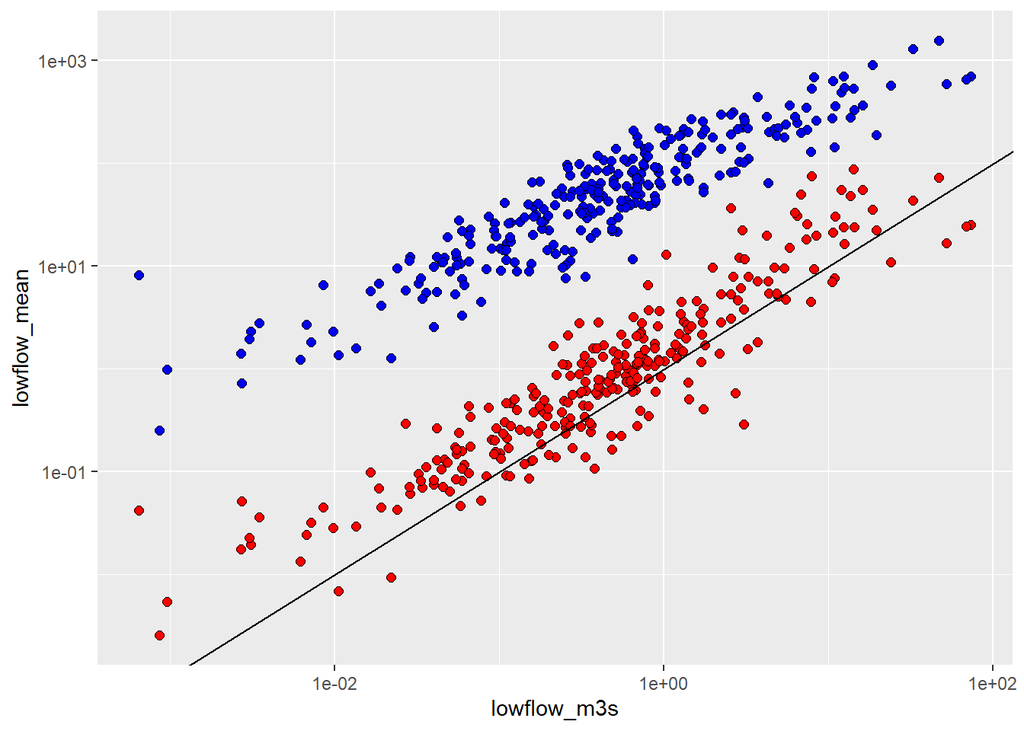

```r
ggplot(dat_indekser,
       aes(lowflow_m3s, lowflow_mean)) +
  geom_point(shape = 21, size = rel(2), fill = "red") +
  geom_point(aes(y=highflow_mean), shape = 21, size = rel(2), fill = "blue2") +
  geom_abline(intercept = 0, slope = 1) +
  scale_x_log10() +
  scale_y_log10()
```

#### Low-water: Test observed/predicted ratio 1

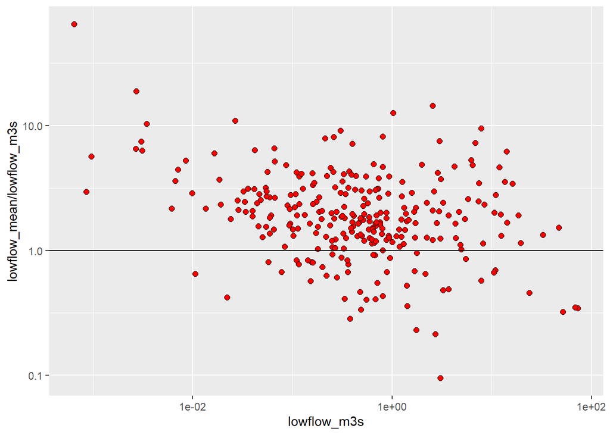

```r
ggplot(dat_indekser,
       aes(lowflow_m3s, lowflow_mean/lowflow_m3s)) +
  geom_point(shape = 21, size = rel(2), fill = "red") +
  geom_hline(yintercept = 1) +
  scale_x_log10() +
  scale_y_log10()
```

#### Low-water: Test observed/predicted ratio 2

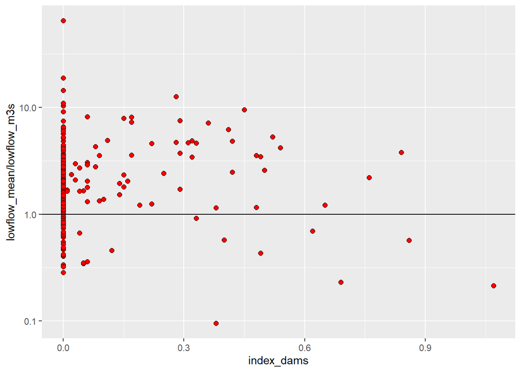

```r
ggplot(dat_indekser,
       aes(index_dams, lowflow_mean/lowflow_m3s)) +
  geom_point(shape = 21, size = rel(2), fill = "red") +
  geom_hline(yintercept = 1) +
  scale_y_log10()
```

#### g. Examine low-water indices vs. indices of hydropower

The index of effect of hydropower on low-water shows a similar pattern, with values around 1 when there are no dams in the catchment of the station. It appears to be more closely linked to the amount of hydropower development in general than to the amount of dams in the catchment.

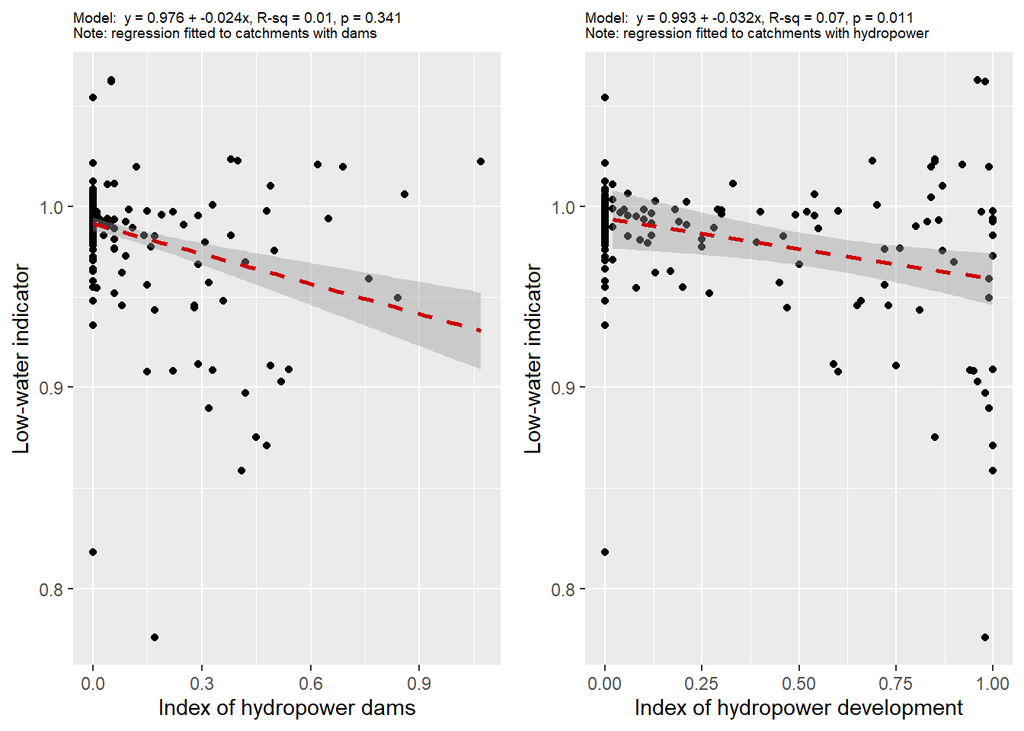

```r
# 1. index_dams

mod <- lm(lowwater_indicator ~ index_dams,
          data = dat_indekser |> filter(index_dams > 0),
          na.action = na.omit)

gg1 <- ggplot(dat_indekser, aes(index_dams, lowwater_indicator)) +
  geom_point() +
  geom_smooth(
    data = dat_indekser |> filter(lowwater_indicator > 0),
    method = "lm", linetype = "dashed", color = "red3") +
  scale_y_log10() +
  labs(x = "Index of hydropower dams", y = "Low-water indicator") +
  labs(subtitle = paste("Model: ", get_model_summ(mod),
       "\nNote: regression fitted to catchments with dams")) +
  theme(plot.subtitle = element_text(size = 7))

# 2. index_regul

mod <- lm(lowwater_indicator ~ index_regul,
          data = dat_indekser |> filter(index_regul > 0),
          na.action = na.omit)

gg2 <- ggplot(dat_indekser, aes(index_regul, lowwater_indicator)) +
  geom_point() +
  geom_smooth(
    data = dat_indekser |> filter(index_regul > 0),
    method = "lm", linetype = "dashed", color = "red3") +
  scale_y_log10() +
  labs(x = "Index of hydropower development", y = "Low-water indicator") +
  labs(subtitle = paste("Model: ", get_model_summ(mod),
       "\nNote: regression fitted to catchments with hydropower")) +
  theme(plot.subtitle = element_text(size = 7))

plot_grid(gg1, gg2, nrow = 1)
```

### 9.5 Check subsets of data

```r
altitude_limit <- 450
altitude_limit_finnmark <- 200
normal_riverflow_limit <- 5
```

As the original dataset has many small rivers, as well as river at high altitudes, we decided do focus on relatively low-lying rivers over a certain size. We selected rivers below 450 m altitude, except in Finnmark (which has lower maximum altitude) where we selected rivers below 200 m. We also selected only rivers above 5 m3/second river flow on average.

#### Add groupings

```r
dat_indekser <- dat_indekser |>
  mutate(
    region = case_when(
      county %in% "Finnmark" ~ "Finnmark",
      county %in% c("Troms", "Finnmark") ~ "Troms og Nordland",
      county %in% c("Trøndelag") ~ "Trøndelag",
      county %in% c("Møre og Romsdal","Vestland","Rogaland") ~ "Vestlandet",
      county %in% c("Agder","Telemark") ~ "Agder og Telemark",
      TRUE ~ "Østlandet"),
    altitude_limit = case_when(
      region %in% "Finnmark" ~ altitude_limit_finnmark,
      TRUE ~ altitude_limit),
    Q_limit = normal_riverflow_limit,
    group1 = case_when(
      altitude < altitude_limit ~ "low",
      altitude >= altitude_limit ~ "high"),
    group2 = case_when(
      altitude < altitude_limit & normalQ_m3s >= Q_limit ~ "low,big",
      altitude < altitude_limit & normalQ_m3s < Q_limit ~ "low,small",
      altitude >= altitude_limit & normalQ_m3s >= Q_limit ~ "high,big",
      altitude >= altitude_limit & normalQ_m3s < Q_limit ~ "high,small"),
    dams = ifelse(index_dams == 0, "no dams", "dams"),
  )
```

#### Map

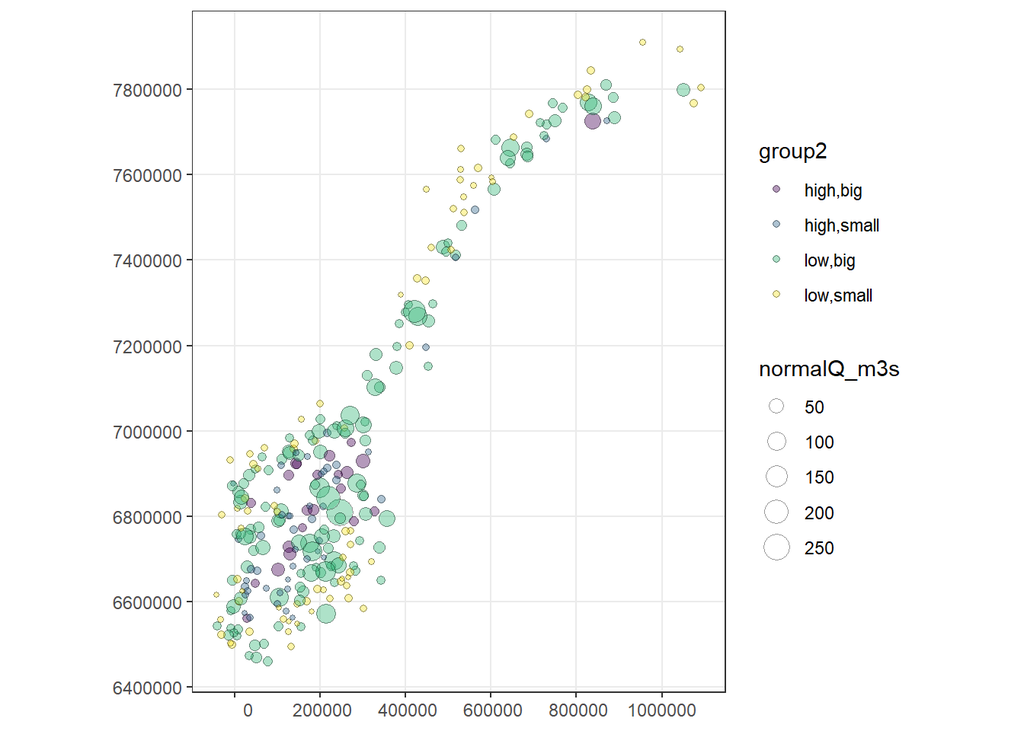

```r
ggplot(dat_indekser) +
  geom_sf(aes(geometry = geom, fill = group2, size = normalQ_m3s),
          shape = 21, alpha = 0.4) +
  scale_fill_viridis_d() +
  theme_bw()
```

#### Altitude vs dams

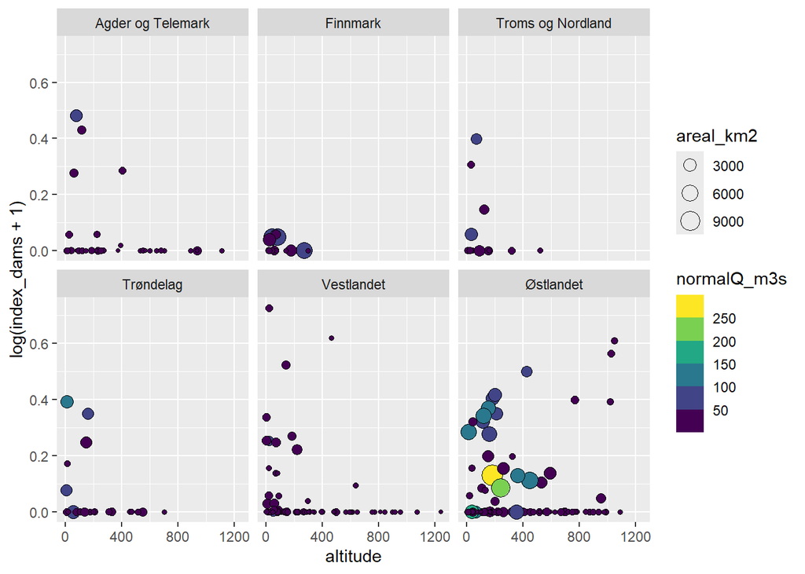

```r
ggplot(dat_indekser, aes(altitude, log(index_dams+1),
                         fill = normalQ_m3s,
                         size = areal_km2)) +
  geom_point(shape = 21) +
  # scale_x_log10() +
  scale_fill_viridis_b() +
  facet_wrap(vars(region))
```

#### Table by groups and dams

```r
dat_indekser |>
  count(group2, index_dams==0)
```

```
      group2 index_dams == 0  n
1   high,big           FALSE  7
2   high,big            TRUE 15
3 high,small           FALSE  2
4 high,small            TRUE 46
5    low,big           FALSE 58
6    low,big            TRUE 75
7  low,small           FALSE  4
8  low,small            TRUE 74
```

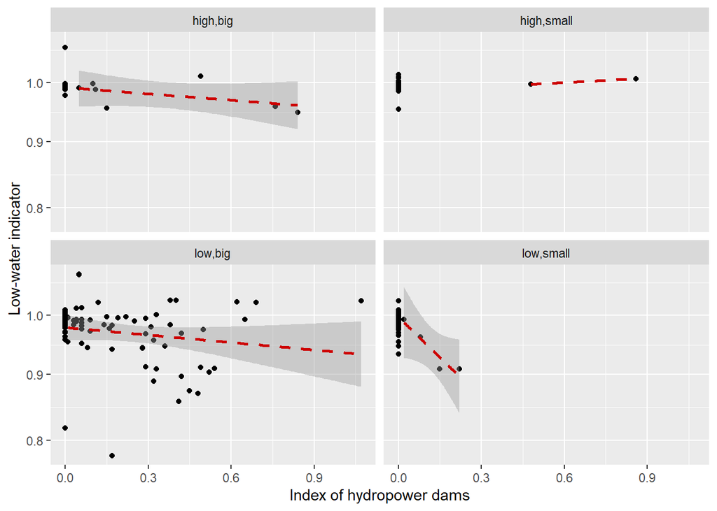

```r
ggplot(dat_indekser, aes(index_dams, lowwater_indicator)) +
  geom_point() +
  geom_smooth(
    data = dat_indekser |> filter(index_dams > 0),
    method = "lm", linetype = "dashed", color = "red3") +
  scale_y_log10() +
  labs(x = "Index of hydropower dams", y = "Low-water indicator") +
  theme(plot.subtitle = element_text(size = 7)) +
  facet_wrap(vars(group2))
```

### 9.6 Make subset to use for the indicators

#### Choose subset:

```r
dat_indekser2 <- dat_indekser |> filter(group2 %in% "low,big")

cat("Selected number in subset:\n")
```

```
Selected number in subset:
```

```r
nrow(dat_indekser2)
```

```
[1] 133
```

```r
cat("Percentage of total:\n")
```

```
Percentage of total:
```

```r
round(100*nrow(dat_indekser2)/nrow(dat_indekser), 1)
```

```
[1] 47.3
```

```r
cat("Selected number of dam-free rivers in subset:\n")
```

```
Selected number of dam-free rivers in subset:
```

```r
sum(dat_indekser2$index_dams == 0)
```

```
[1] 75
```

```r
cat("Percentage of total:\n")
```

```
Percentage of total:
```

```r
round(100*sum(dat_indekser2$index_dams == 0)/nrow(dat_indekser2), 1)
```

```
[1] 56.4
```

#### Table - mean low-water indicator

```r
dat_indekser |>
  group_by(group2) |>
  summarise(
    lowwater_indicator_zerodams = mean(lowwater_indicator),
    n = n()
  )
```

```
# A tibble: 4 × 3
  group2     lowwater_indicator_zerodams     n
  <chr>                            <dbl> <int>
1 high,big                         0.992    22
2 high,small                       0.995    48
3 low,big                          0.981   133
4 low,small                        0.989    78
```

```r
dat_indekser |>
  filter(index_dams == 0) |>
  group_by(group2) |>
  summarise(
    lowwater_indicator = mean(lowwater_indicator),
    n = n()
  )
```

```
# A tibble: 4 × 3
  group2     lowwater_indicator     n
  <chr>                   <dbl> <int>
1 high,big                0.999    15
2 high,small              0.995    46
3 low,big                 0.990    75
4 low,small               0.992    74
```

### 9.7 Calculate flood indicator

We create the final flood indicator based on the flood index. Ideally, the flood index should be 1 for the mean of rivers (within the chosen subset) with no dams in their catchment (reference condition). However, it turns out to be signinficanly higher:

```r
mod <- lm(flood_index ~ 1, data = subset(dat_indekser2, dams == "no dams"))
summary(mod)$coef
```

```
            Estimate Std. Error  t value    Pr(>|t|)
(Intercept) 1.124761 0.03061497 36.73893 2.89514e-49
```

Thus, we create a flood indicator which should be 1 for the mean of rivers (within the chosen subset) with no dams in their catchment (reference condition), and 0 for rivers where the annual flood has been reduced to 20% of the origican flood size, which we take to be no flood in an ecological sense:

$$\text{Flood\_indicator}_i = \begin{cases} \dfrac{\text{Flood\_index}_i - 0.2} {\text{Flood\_index}_{\text{reference}} - 0.2}, & \text{if Flood\_index}_i \ge 0.2, \\[1ex] 0, & \text{if Flood\_index}_i < 0.2. \end{cases}$$

where $Flood\_index_{\text{reference}}$ is the mean flood index for rivers with no dams in their catchment.

```r
# Reference level 1 = mean for rivers without dams
ref_1 <- mean(subset(dat_indekser2, dams == "no dams")$flood_index)
ref_0 <- 0.20
```

$Flood\_index_{\text{reference}}$ was found to be 1.1247615

The relationship between the flood indicator and the flood index is shown below:

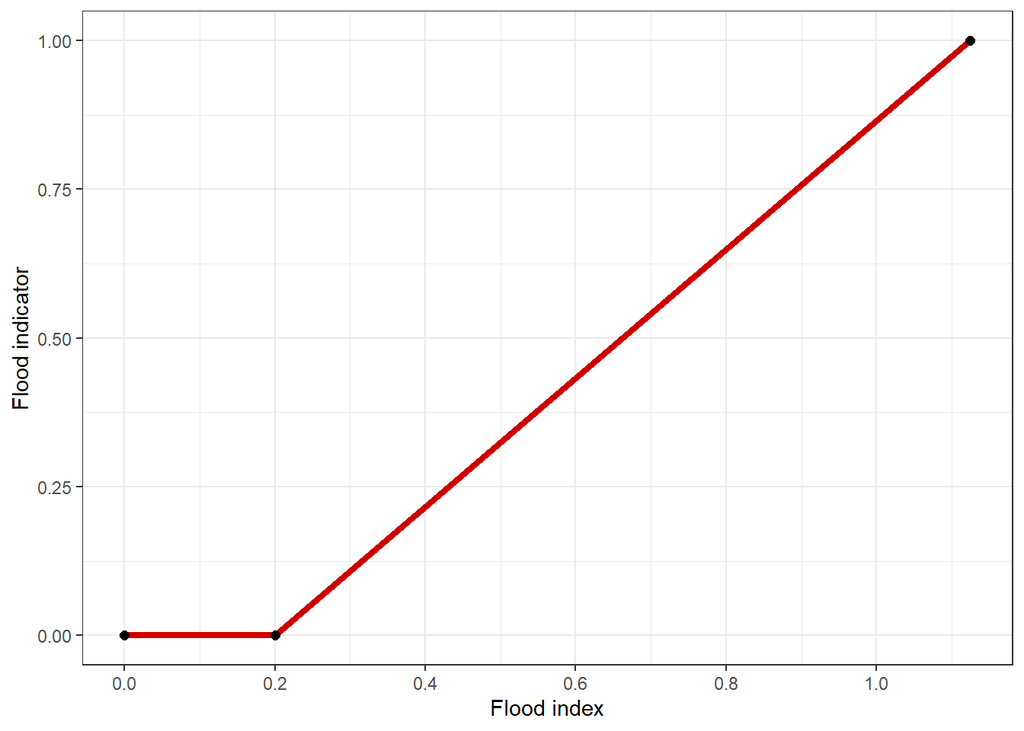

```r
ggplot(data = data.frame(x=c(0,0.2,ref_1), y=c(0,0,1)), aes(x=x, y=y)) +
  geom_segment(x = 0, y = 0, xend = ref_0, yend = 0, color = "red3", linewidth = 1.5) +
  geom_segment(x = ref_0, y = 0, xend = ref_1, yend = 1, color = "red3", linewidth = 1.5) +
  scale_x_continuous(breaks = seq(0,1,0.2)) +
  geom_point(size = 2) +
  theme_bw() +
  labs(
    x = "Flood index", y = "Flood indicator"
  )
```

The $Flood\_index_{\text{reference}}$ was found to be 1.1247615.

```r
# relatively low-lying rivers over a certain size = data set "dat_indekser2"


# table(dat_indekser2$dams)
dat_indekser2 <- dat_indekser2 |>
  mutate(
    flood_indicator = (flood_index - ref_0)/(ref_1 - ref_0),
    dam_weight = ifelse(dams == "dams", 0.7, 0.3)
  )

# check
# mean(subset(dat_indekser2, dams == "no dams")$flood_indicator)
# range(dat_indekser2$flood_indicator)
```

#### Plot

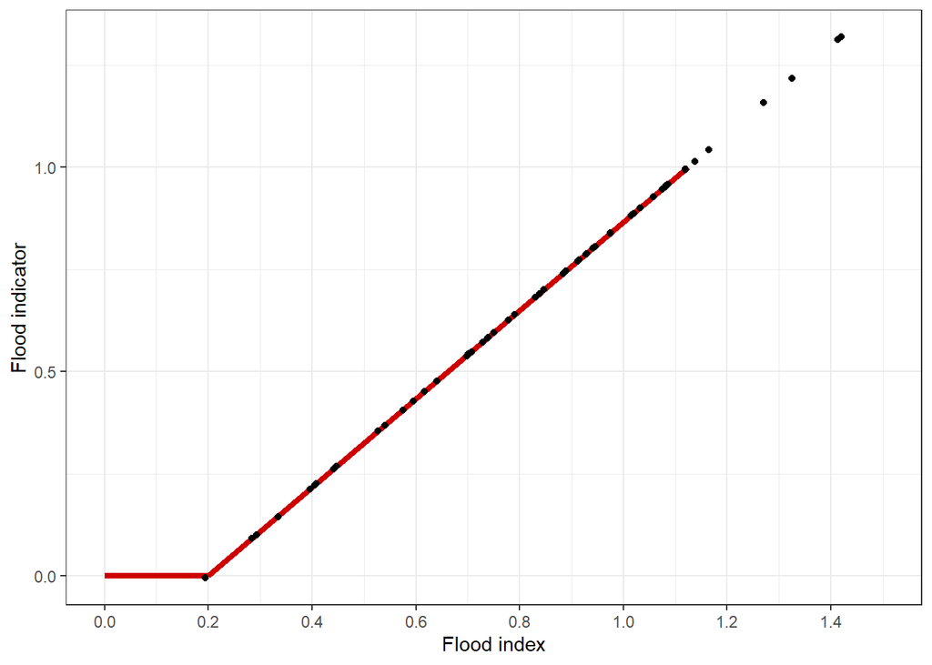

```r
ggplot(dat_indekser2 |> filter(dams == "dams"),
       aes(x = flood_index, y = flood_indicator)) +
  geom_segment(x = 0, y = 0, xend = 0.2, yend = 0, color = "red3", linewidth = 1.5) +
  geom_segment(x = 0.2, y = 0, xend = ref_1, yend = 1, color = "red3", linewidth = 1.5) +
  geom_point() +
  scale_x_continuous(breaks = seq(0,1.8,0.2), limits = c(0,1.5)) +
  theme_bw() +
  labs(
    x = "Flood index", y = "Flood indicator"
  )
```

#### Figure: flood index vs dams

After selection of subset: flood index vs dams.

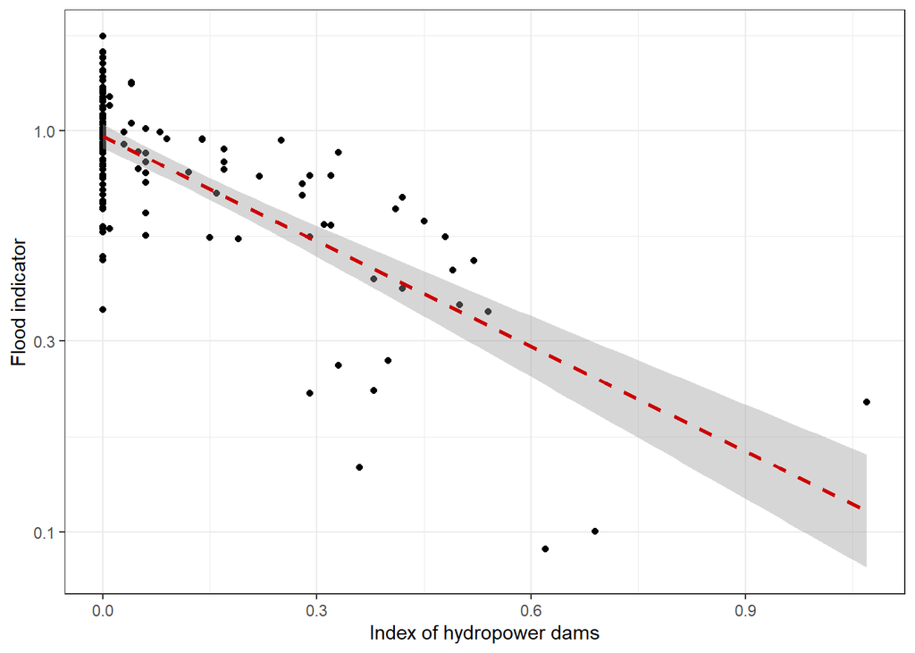

```r
ggplot(dat_indekser2, aes(index_dams, flood_indicator)) +
  geom_point() +
  geom_smooth(
    # data = flood_indicator |> filter(index_dams > 0),
    method = "lm", linetype = "dashed", color = "red3") +
  scale_y_log10() +
  labs(x = "Index of hydropower dams", y = "Flood indicator") +
  theme(plot.subtitle = element_text(size = 7)) +
  theme_bw()
```